# 決定木アルゴリズム

データへの適合

川田恵介

## 概念: 予測モデル

- 予測モデル(関数) : 指定された $X$ について、 $Y$ の予測値を自動回答する”機械 (AI)”
  - 江古田駅から徒歩5分、1LDKの中古マンションの予想販売価格
- データを用いて、作成

## コア・アイディア

- 全ての事例は、 他の事例にも適用できる一般的な特徴 (シグナル) とその事例だけが持つ一般化できない特徴 (ノイズ) をもつ
1. モデルをデータに適合されることで、 データの持つ”シグナル”を抽出
2. 事例を集約することで、 データの持つ”ノイズ”を除去
3. 1と2をバランスさせるモデルの複雑さを、独立したデータへの適合で決める

## 例

- 学園祭出店の仕入担当: 去年の事例から、仕入れ量を決定
  - $X$ : 記録されている属性 (販材、規模)、 $Y$ : 販売量
- 今年出展する出店 $X = \{$ わたあめ, 2名 $\}$ の販売量を予測
- チャレンジ: 一般に $Y = "X"共通要因 + 観察できない要因$
  - 可能な限り”共通要因”の特徴を捉えたい!!!

# データ主導のモデリング

- アルゴリズム $\simeq$ 推定手法
- 決定木 $=$ 優れた出発点
  - **データに適合させる**モデリング法を学ぶ

## 予測モデル(関数)

- $X$ が決まれば、 $Y$ の予測値が決まる
- $g(X)$ と表現
- 分析者による決定 $+$ データによる決定
  - 現代的アプローチ: より多くをデータが決定

## サブグループ分析

- “もっとも”よく使われるデータ活用方法
- 属性 $X$ についてサブグループ $A$ を定義し、 予測モデル $g(X)$ をサブグループ平均として定義

## 例

```
# A tibble: 6 × 4
   Size Location DistanceStation Price
  <int> <chr>              <int> <int>
1    87 練馬                  18     7
2    58 練馬                  19     9
3    20 練馬                   1     5
4    53 板橋                  10     5
5    62 板橋                  14     9
6    33 板橋                  10     9
```

- $\{$ 練馬 & 広さ = 30 & 駅からの距離 = 2分 $\}\simeq$ 予測販売価格?

## 例: 立地

```
# A tibble: 6 × 6
   Size Location DistanceStation Price SubGroup Prediction
  <int> <chr>              <int> <int> <chr>         <dbl>
1    87 練馬                  18     7 練馬              7
2    58 練馬                  19     9 練馬              7
3    20 練馬                   1     5 練馬              7
4    53 板橋                  10     5 板橋              8
5    62 板橋                  14     9 板橋              8
6    33 板橋                  10     9 板橋              8
```

- $\{$ 練馬 & 広さ = 30 & 駅からの距離 = 2分 $\}\simeq 7$

## 例: 立地 & 広さ

```
# A tibble: 6 × 6
   Size Location DistanceStation Price SubGroup          Prediction
  <int> <chr>              <int> <int> <chr>                  <dbl>
1    87 練馬                  18     7 練馬 & Size > 50           8
2    58 練馬                  19     9 練馬 & Size > 50           8
3    20 練馬                   1     5 練馬 & Size <= 50          5
4    53 板橋                  10     5 板橋 & Size > 50           7
5    62 板橋                  14     9 板橋 & Size > 50           7
6    33 板橋                  10     9 板橋 & Size <= 50          9
```

- $\{$ 練馬 & 広さ = 30 & 駅からの距離 = 2分 $\}\simeq 5$

## 二乗誤差最小化

- サブグループ平均 $=$ 最もサブグループに”適合する”値
- 各サブグループ内の平均二乗誤差 (Mean Squared Error)を最小化する

$$E[(Y-g(X_i))^2|A]$$

## 例

```
# A tibble: 6 × 9
   Size Location DistanceStation Price SubGroup  Mean   Max MSE_Mean MSE_Max
  <int> <chr>              <int> <int> <chr>    <dbl> <dbl>    <dbl>   <dbl>
1    87 練馬                  18     7 練馬         7     9        0       4
2    58 練馬                  19     9 練馬         7     9        4       0
3    20 練馬                   1     5 練馬         7     9        4      16
4    53 板橋                  10     5 板橋         8     9        9      16
5    62 板橋                  14     9 板橋         8     9        1       0
6    33 板橋                  10     9 板橋         8     9        1       0
```

## “伝統的” VS Data adaptive modelling

- 伝統的アプローチ: 研究者が事前(データを見る前)にサブグループを定義
  - サブグループごとの予測値のみ、データに適合するように決定
- Data adaptive: グループ分けもデータに適合するように決定
- (注) “Bad practice” : 研究者がデータ $\{Y,X\}$ を見ながらサブグループを決定

## 伝統的アプローチ

1. 研究者が事前にサブグループを定義
2. 各サブグループについて、サンプル平均を計算し、予測モデルを構築
- 樹形図で可視化可能

## 実例: 伝統的アプローチ

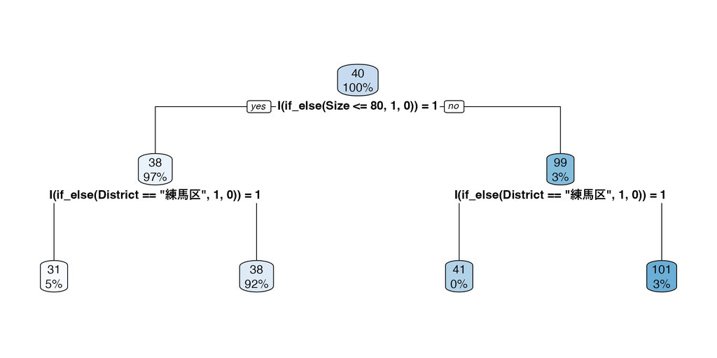

## 実例: 伝統的アプローチ

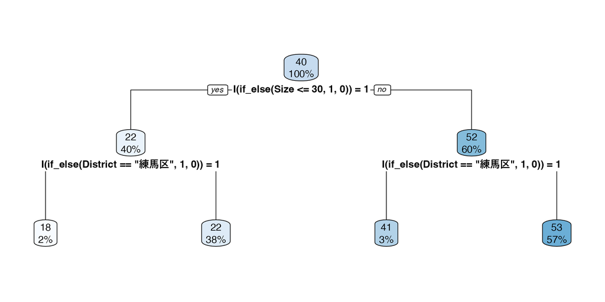

## 伝統的アプローチの問題点

- サブグループ分けに決定的に依存する
- 予測研究においては、サブグループを定義する際の、 **Practical** guide lineが限られている
  - 比較・因果研究であれば、研究課題により自動的に決まる部分がある (例: 大卒高卒間賃金格差 $=$ 少なくとも大卒/高卒でグループ分け)
- 予測結果は、グループの定義に決定的な影響を受ける
  - 予測モデルに活用しない変数も指定する必要がある

## Data adaptive アプローチ

0. 停止条件(最大いくつのサブグループを作るかなど)を設定
1. データに適合するように、サブグループを設定
2. 各サブグループについて、サンプル平均を計算し、予測モデルを構築
- 課題: 具体的には？

## 貪欲な (Greedy) アルゴリズム

0. 停止条件を設定
1. 2分割する: データ内二乗誤差を最小化するように一つの変数、閾値を選ぶ
2. 1度目の分割を”所与”として、２度目の分割を行う
3. 停止条件に達するまで、繰り返す

## 実例: 停止条件 = 2回分割

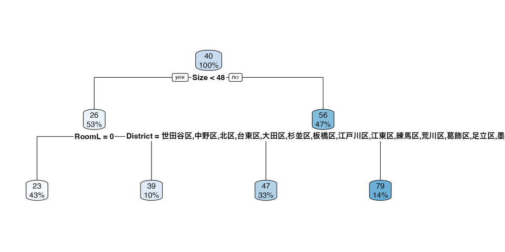

## Data adaptive アプローチの課題

- モデルが停止条件に決定的な影響を受ける
- 停止条件を緩める (最大分割回数を増やす, 最小サンプルサイズを減らす) と巨大な (複雑な) 決定木が生成される

## 実例: 停止条件: 3回分割

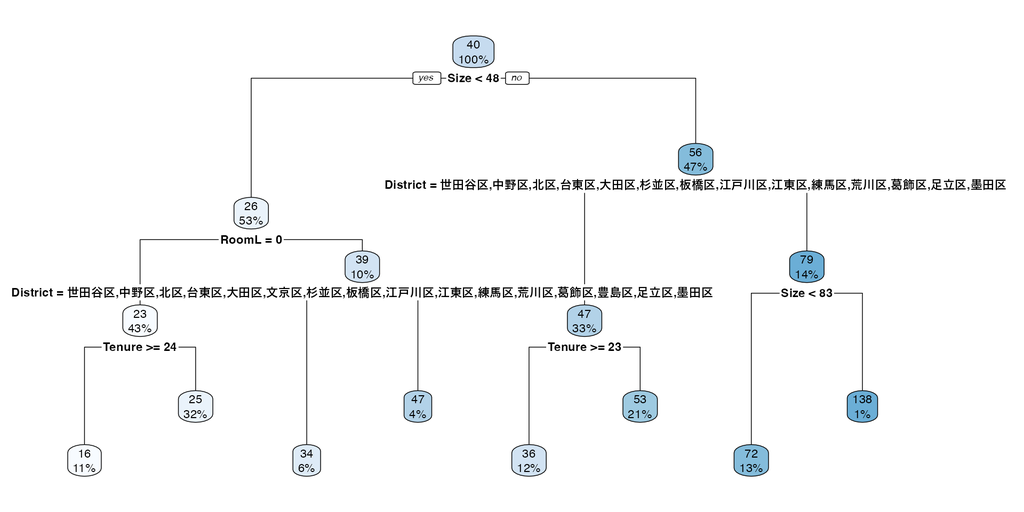

## 実例: 停止条件: 5回分割

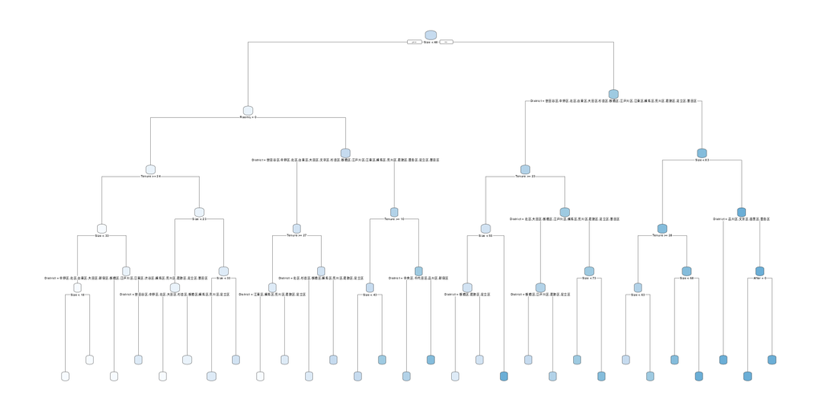

## Data adaptive アプローチの課題

- “停止条件をどのように決める?”
- 異なる条件のもとで、モデルの試作と中間評価を繰り返し、最善の条件を探す
  - データへの当てはまり 😨
  - 独立して抽出されたデータへの当てはまり 😄
  - 理論的評価指標 (AICなど) 🙄

## “データへの適合”の限界

- データに適合するように停止条件を決めると何が起きるか?
  - 最もデータに適合する予測木は?

## 複雑すぎる予測モデル

- データに適合するように停止条件を決めると、 丸暗記方予測モデル (極めて複雑な予測モデル) が出来上がる
- $X$ の数が十分あれば、全く同じ $X$ をもつ事例はデータ内に一つしかない決定木 (巨大な決定木)が生成できる
  - データとの矛盾がなくなる
  - 予測値 $=$ 最も近い1事例の値

## まとめ

- 「データに適合させる」は、データ分析の基本戦略
- 現代のPCを使えば、サブグループ分け自体もデータによって決められる
- **厳重注意** データに適合するように停止条件(モデルの複雑さ)を選ぶと、極めて複雑・データに適合するが、予測性能が劣悪なモデルが出来上がる
  - 現実が複雑であったとしても、一般に劣悪なモデルが出来上がる
- なぜか?
  - 事例の集計ができなくなるため